# Introduction to Latent Transition Analysis (LTA) with MplusAutomation

Adam Garber: MM4DBER Training Team

Updated: November 29, 2023

[figure not shown]

[figure not shown]

# ________________________________________________________________________

# Outline

**0. Preparation**

**1. Enumerate time specific LCAs independently**

**2. Estimate LTA models**

**3. Evaluate the invariance assumption**

**4. Examine transition estimates**

# ________________________________________________________________________

# Preparation

**Download the R-Project**

Link to Github repository here: https://github.com/MM4DBER/Intro-to-LTA

**Project folder organization**

The following sub-folders will be used to contain files:

1. `data`; 2. `enum_LCA_time1`; 3. `enum_LCA_time2`; 4. `LTA_models`; 5. `figures`

**Note regarding project location:** If the main project folder is located within too many nested folders it may result in a file-path error when estimating models with MplusAutomation.

*Notation guide*

In the following script, three types of comments are included in code blocks in which models are estimated using MplusAutomation.

1. **Annotate in R:** The hashtag symbol `#` identifies comments written in R-language form.
2. **Annotate in Mplus input:** Within the `mplusObject()` function all text used to generate Mplus input files is enclosed within quotation marks (green text). To add comments within quotations the Mplus language convention is used (e.g., !!! annotate Mplus input !!!).
3. **Annotate context-specific syntax:** To signal to the user areas of the syntax which vary based on the particular modeling context the text, `NOTE CHANGE:` is used. This syntax will change based on your applied example (e.g., class #).

To install package {`rhdf5`}

```r
if (!requireNamespace("BiocManager", quietly = TRUE))
  install.packages("BiocManager")

BiocManager::install("rhdf5")
```

Load packages

```r
library(MplusAutomation)
library(rhdf5)
library(tidyverse)
library(here)
library(glue)
library(gt)
library(reshape2)
library(cowplot)
library(patchwork)
library(PNWColors)
library(ggrepel)
```

Read in the LSAY data file named `lsay_lta_faq_2021.csv`.

```r
lsay_data <- read_csv(here("data","lsay_lta_faq_2021.csv"),
                      na=c("9999","9999.00"))
```

# ________________________________________________________________________

# Enumeration

Enumeration for each time point is done independently first, then the results are compared.

## Enumerate Time Point 1 (7th grade)

```r
# NOTE CHANGE: '1:6' indicates the number of k-class models to estimate
# User can change this number to fit research context
# In this example, the code loops or iterates over values 1 through 6 ( '{k}' )
#
t1_enum_k_16  <- lapply(1:6, function(k) {
  enum_t1  <- mplusObject(

# The 'glue' function inserts R code within a string or "quoted green text" using the syntax {---}

  TITLE = glue("Class-{k}_Time1"),

  VARIABLE = glue(
     "!!! NOTE CHANGE: List of the five 7th grade science attitude indicators !!!
      categorical = ab39m ab39t ab39u ab39w ab39x  ! 7th grade indicators
           usevar = ab39m ab39t ab39u ab39w ab39x

      classes = c({k});"),

  ANALYSIS =
     "estimator = mlr;
      type = mixture;
      !!! NOTE CHANGE: The intial and final start values. Reduce to speed up estimation time. !!!
      starts = 500 100;
      processors = 10;",

  OUTPUT = "sampstat residual tech11 tech14;",

  PLOT =
     "type = plot3;
      series = ab39m-ab39x(*);",

  usevariables = colnames(lsay_data),
  rdata = lsay_data)

# NOTE CHANGE: Fix to match appropriate sub-folder name (e.g., "enum_LCA_time1")
enum_t1_fit <- mplusModeler(enum_t1,
                 dataout = here("enum_LCA_time1", "t1.dat"),
                 modelout = glue(here("enum_LCA_time1", "c{k}_lca_enum_time1.inp")),
                 check = TRUE, run = TRUE, hashfilename = FALSE)
})
```

**NOTE:** It is highly recommended that you check the Mplus output files (`.out`) to check for convergence warnings or syntax errors. Mplus files may be viewed in the `RStudio` window (bottom right pane).

## Enumerate Time Point 2 (10th grade)

```r
t2_enum_k_16  <- lapply(1:6, function(k) {
  enum_t2  <- mplusObject(

  TITLE = glue("Class-{k}_Time2"),

  VARIABLE = glue(
     "!!! NOTE CHANGE: List of the five 10th grade science attitude indicators !!!
      categorical = ga33a ga33h ga33i ga33k ga33l;
           usevar = ga33a ga33h ga33i ga33k ga33l;

      classes = c({k});"),

  ANALYSIS =
     "estimator = mlr;
      type = mixture;
      starts = 500 100;
      processors = 10;",

  OUTPUT = "sampstat residual tech11 tech14;",

  PLOT =
     "type = plot3;
      series = ga33a-ga33l(*);",

  usevariables = colnames(lsay_data),
  rdata = lsay_data)

enum_t2_fit <- mplusModeler(enum_t2,
                 dataout = here("enum_LCA_time2", "t2.dat"),
                 modelout = glue(here("enum_LCA_time2", "c{k}_lca_enum_time2.inp")),
                 check = TRUE, run = TRUE, hashfilename = FALSE)
})
```

## Create Model Fit Summary Table

Once you decice on the number of classes for each time point, presenting them in one table is useful for the publicatoin. The following syntax for producing publication ready fit tables can be cited using the following citation:

Garber, A. C. (2021). Creating Summary Fit Tables for LCA and LTA Analyses Using MplusAutomation. [$\color{blue}{\text{Retrieved from psyarxiv.com/uq2fh}}$](https://psyarxiv.com/uq2fh)

Read all models for enumeration table

```r
output_enum_t1 <- readModels(here("enum_LCA_time1"), quiet = TRUE)
output_enum_t2 <- readModels(here("enum_LCA_time2"), quiet = TRUE)
```

Extract model fit data

```r
enum_extract1 <- LatexSummaryTable(output_enum_t1,
                keepCols = c("Title", "Parameters", "LL", "BIC", "aBIC",
                           "BLRT_PValue", "T11_VLMR_PValue","Observations"))

enum_extract2 <- LatexSummaryTable(output_enum_t2,
                keepCols = c("Title", "Parameters", "LL", "BIC", "aBIC",
                           "BLRT_PValue", "T11_VLMR_PValue","Observations"))
```

Calculate Indices Derived from the Log Likelihood (LL)

```r
allFit <- rbind(enum_extract1, enum_extract2) %>%
  mutate(aBIC = -2*LL+Parameters*log((Observations+2)/24)) %>%
  mutate(CAIC = -2*LL+Parameters*(log(Observations)+1)) %>%
  mutate(AWE = -2*LL+2*Parameters*(log(Observations)+1.5)) %>%
  mutate(SIC = -.5*BIC) %>%
  mutate(expSIC = exp(SIC - max(SIC))) %>%
  mutate(BF = exp(SIC-lead(SIC))) %>%
  mutate(cmPk = expSIC/sum(expSIC)) %>%
  select(1:5,9:10,6:7,13,14)
```

Format fit table

```r
allFit %>%
  mutate(Title = str_remove(Title, "_Time.")) %>%
  gt() %>%
  tab_header(
    title = md("**Model Fit Summary Table**"), subtitle = md("&nbsp;")) %>%
  cols_label(
    Title = "Classes",
    Parameters = md("Par"),
    LL = md("*LL*"),
    T11_VLMR_PValue = "VLMR",
    BLRT_PValue = "BLRT",
    BF = md("BF"),
    cmPk = md("*cmPk*")) %>%
  tab_footnote(
    footnote = md(
    "*Note.* Par = Parameters; *LL* = model log likelihood;
      BIC = Bayesian information criterion;
      aBIC = sample size adjusted BIC; CAIC = consistent Akaike information criterion;
      AWE = approximate weight of evidence criterion;
      BLRT = bootstrapped likelihood ratio test p-value;
      VLMR = Vuong-Lo-Mendell-Rubin adjusted likelihood ratio test p-value;
      *cmPk* = approximate correct model probability."),
    locations = cells_title()) %>%
  tab_options(column_labels.font.weight = "bold",
              row_group.font.weight = "bold") %>%
  fmt_number(10,decimals = 2, drop_trailing_zeros=TRUE, suffixing = TRUE) %>%
  fmt_number(c(3:9,11), decimals = 2) %>%
  fmt_missing(1:11, missing_text = "--") %>%
  fmt(c(8:9,11), fns = function(x)
    ifelse(x<0.001, "<.001", scales::number(x, accuracy = 0.01))) %>%
  fmt(10, fns = function(x)
    ifelse(x>100, ">100", scales::number(x, accuracy = .1))) %>%
  tab_row_group(group = "Time-1",rows = 1:6) %>%
  tab_row_group(group = "Time-2",rows = 7:12) %>%
  row_group_order(groups = c("Time-1","Time-2"))
```

**Model Fit Summary Table**<sup>1</sup>

| Classes | Par | *LL* | BIC | aBIC | CAIC | AWE | BLRT | VLMR | BF | *cmPk* |
| --- | --- | --- | --- | --- | --- | --- | --- | --- | --- | --- |
| Time-1 |  |  |  |  |  |  |  |  |  |  |
| Class-1 | 5 | −10,250.60 | 20,541.34 | 20,525.45 | 20,546.34 | 20,596.47 | – | – | 0.0 | <.001 |
| Class-2 | 11 | −8,785.32 | 17,658.92 | 17,623.97 | 17,669.93 | 17,780.22 | <.001 | <.001 | 0.0 | <.001 |
| Class-3 | 17 | −8,693.57 | 17,523.59 | 17,469.57 | 17,540.59 | 17,711.04 | <.001 | <.001 | 0.0 | <.001 |
| Class-4 | 23 | −8,664.09 | 17,512.79 | 17,439.71 | 17,535.79 | 17,766.40 | <.001 | <.001 | >100 | <.001 |
| Class-5 | 29 | −8,662.39 | 17,557.54 | 17,465.40 | 17,586.54 | 17,877.31 | 1.00 | 0.66 | >100 | <.001 |
| Class-6 | 35 | −8,661.54 | 17,604.01 | 17,492.80 | 17,639.01 | 17,989.94 | 0.67 | 0.94 | 0.0 | <.001 |
| Time-2 |  |  |  |  |  |  |  |  |  |  |
| Class-1 | 5 | −7,553.22 | 15,144.99 | 15,129.10 | 15,149.99 | 15,198.53 | – | – | 0.0 | <.001 |
| Class-2 | 11 | −5,988.12 | 12,061.04 | 12,026.09 | 12,072.04 | 12,178.83 | <.001 | <.001 | 0.0 | <.001 |
| Class-3 | 17 | −5,903.07 | 11,937.17 | 11,883.16 | 11,954.17 | 12,119.22 | <.001 | <.001 | 1.4 | 0.58 |
| Class-4 | 23 | −5,880.25 | 11,937.79 | 11,864.71 | 11,960.79 | 12,184.08 | <.001 | 0.00 | >100 | 0.42 |
| Class-5 | 29 | −5,877.60 | 11,978.74 | 11,886.60 | 12,007.74 | 12,289.28 | 0.67 | 0.70 | >100 | <.001 |
| Class-6 | 35 | −5,877.07 | 12,023.94 | 11,912.74 | 12,058.94 | 12,398.73 | 1.00 | 0.17 | – | <.001 |

<sup>1</sup> *Note.* Par = Parameters; *LL* = model log likelihood; BIC = Bayesian information criterion; aBIC = sample size adjusted BIC; CAIC = consistent Akaike information criterion; AWE = approximate weight of evidence criterion; BLRT = bootstrapped likelihood ratio test p-value; VLMR = Vuong-Lo-Mendell-Rubin adjusted likelihood ratio test p-value; *cmPk* = approximate correct model probability.

## Compare Time 1 & Time 2 Condition Item Probability Plots

For a publication, you will want to present the conditional item probability plot for each time point. The code below will create the plots for each time point.

Read models for plotting (4-class models)

```r
model_t1_c4 <- readModels(here("enum_LCA_time1", "c4_lca_enum_time1.out"), quiet = TRUE)
model_t2_c4 <- readModels(here("enum_LCA_time2", "c4_lca_enum_time2.out"), quiet = TRUE)
```

Create a function called `plot_lca_function` that requires 7 arguments (inputs):

- `model_name`: Name of Mplus model object (e.g., `model_step1`)
- `item_num`: The number of items in LCA measurement model (e.g., `5`)
- `class_num`: The number of classes (*K*) in LCA model (e.g., `4`)
- `item_labels`: The item labels for x-axis (e.g., `c("Enjoy","Useful","Logical","Job","Adult")`)
- `class_labels`: The class label names (e.g., `c("Pro-Science","Amb. w/ Minimal","Amb. w/ Elevated","Anti-Science")`)
- `class_legend_order` = Change the order that class names are listed in the plot legend (e.g., `c(1,3,2,4)`)
- `plot_title`: Include the title of the plot here (e.g., `"Conditional Item Probability Plot"`)

```r
plot_lca_function <- function(model_name,item_num,class_num,item_labels,
                              class_labels,class_legend_order,plot_title){

mplus_model <- as.data.frame(model_name$gh5$means_and_variances_data$estimated_probs$values)
plot_data <- mplus_model[seq(2, 2*item_num, 2),]

c_size <- as.data.frame(model_name$class_counts$modelEstimated$proportion)
colnames(c_size) <- paste0("cs")
c_size <- c_size %>% mutate(cs = round(cs*100, 2))
colnames(plot_data) <- paste0(class_labels, glue(" ({c_size[1:class_num,]}%)"))
plot_data <- plot_data %>% relocate(class_legend_order)

plot_data <- cbind(Var = paste0("U", 1:item_num), plot_data)
plot_data$Var <- factor(plot_data$Var,
               labels = item_labels)
plot_data$Var <- fct_inorder(plot_data$Var)

pd_long_data <- melt(plot_data, id.vars = "Var")

# This syntax uses the data.frame created above to produce the plot with `ggplot()`

p <- pd_long_data %>%
  ggplot(aes(x = as.integer(Var), y = value,
  shape = variable, colour = variable, lty = variable)) +
  geom_point(size = 4) + geom_line() +
  scale_x_continuous("", breaks = 1:item_num, labels = plot_data$Var) +
  scale_colour_grey() +
  labs(title = plot_title, y = "Probability") +
  theme_cowplot() +
  theme(legend.title = element_blank(),
        legend.position = "top") +
  coord_cartesian(xlim = c(.9, 5.4), ylim = c(-.05, 1.05), expand = FALSE)

p
return(p)
}
```

### Time 1 LCA - Conditional Item Probability Plot

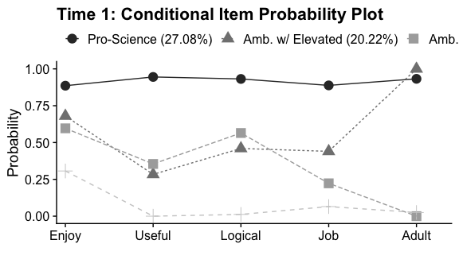

```r
plot_lca_function(
  model_name = model_t1_c4,
  item_num = 5,
  class_num = 4,
  item_labels = c("Enjoy","Useful","Logical","Job","Adult"),
  class_labels = c("Pro-Science","Amb. w/ Minimal","Amb. w/ Elevated","Anti-Science"),
  class_legend_order = c(1,3,2,4),
  plot_title = "Time 1: Conditional Item Probability Plot"
  )
```

```r
ggsave(here("figures", "T1_C4_LCA_plot.png"), dpi=300, height=5, width=7, units="in")
```

### Time 2 LCA - Conditional Item Probability Plot

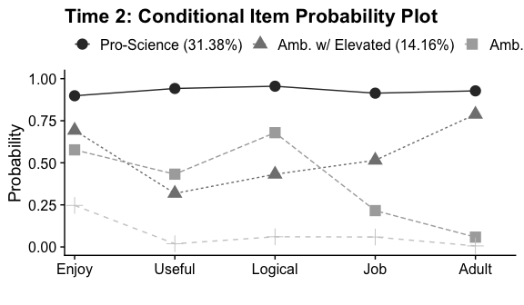

```r
plot_lca_function(
  model_name = model_t2_c4,
  item_num = 5,
  class_num = 4,
  item_labels = c("Enjoy","Useful","Logical","Job","Adult"),
  class_labels = c("Pro-Science","Anti-Science","Amb. w/ Elevated","Amb. w/ Minimal"),
  class_legend_order = c(1,3,4,2),
  plot_title = "Time 2: Conditional Item Probability Plot"
  )
```

```r
ggsave(here("figures", "T2_C4_LCA_plot.png"), dpi=300, height=5, width=7, units="in")
```

# ________________________________________________________________________

# Estimate Latent Transition Analysis Models (LTA)

When fitting the LTA model with two time points, it is possible to test if the latent classes at each time point are the same. If the same number and type of classes emerge at each time point, it may be meaningful to test if the measurement model can be the same at each time point. So this is asking the question, “Are the latent classes at time 1 the same at time 2?”. Note that the class sizes do not need to be equal.

> Non-invariant LTA model: The classes are **NOT** held (or constrained) equal at each time point.

> Invariant LA model: Classes **ARE** held equal at each time point. Note that this model is more parsimonious and thus would be preferred if there is statistical support for it.

These nested model tests are highly sensitive- so even if the test below indicates that the invariant model (holding classes the same across time points) significantly increases model misfit, it still may be reasonable to use the invariant model if the classes look the same.

## Estimate Non-Invariant LTA Model

```r
lta_non_inv <- mplusObject(

  TITLE =
    "LTA (Non-Invariant)",

  VARIABLE =
     "usevar = ab39m ab39t ab39u ab39w ab39x  ! 7th grade indicators
             ga33a ga33h ga33i ga33k ga33l;   ! 10th grade indicators

      categorical = ab39m-ab39x ga33a-ga33l;

      classes = c1(4) c2(4);",

  ANALYSIS =
     "estimator = mlr;
      type = mixture;
      starts = 500 100;
      processors=10;",

  MODEL =
     "%overall%
      c2 on c1; !!! estimate all multinomial logistic regressions !!!

      MODEL c1: !!! the following syntax will allow item thresholds !!!
                !!! to be estimated for each class (e.g. noninvariance) !!!

      %c1#1%
      [AB39M$1-AB39X$1];
      %c1#2%
      [AB39M$1-AB39X$1];
      %c1#3%
      [AB39M$1-AB39X$1];
      %c1#4%
      [AB39M$1-AB39X$1];

      MODEL c2:
      %c2#1%
      [GA33A$1-GA33L$1];
      %c2#2%
      [GA33A$1-GA33L$1];
      %c2#3%
      [GA33A$1-GA33L$1];
      %c2#4%
      [GA33A$1-GA33L$1];",

  OUTPUT = "tech1 tech15 svalues;",

  usevariables = colnames(lsay_data),
  rdata = lsay_data)

lta_non_inv_fit <- mplusModeler(lta_non_inv,
                     dataout=here("LTA_models", "lta.dat"),
                     modelout=here("LTA_models", "lta-non-invariant.inp"),
                     check=TRUE, run = TRUE, hashfilename = FALSE)
```

## Estimate Invariant LTA Model

```r
lta_inv <- mplusObject(

  TITLE =
     "LTA (Invariant)",

  VARIABLE =
     "usevar = ab39m ab39t ab39u ab39w ab39x  ! 7th grade indicators
             ga33a ga33h ga33i ga33k ga33l; ! 10th grade indicators

      categorical = ab39m-ab39x ga33a-ga33l;

      classes = c1(4) c2(4);",

  ANALYSIS =
     "estimator = mlr;
      type = mixture;
      starts = 500 100;
      processors=10;",

  MODEL =
     "%overall%
      c2 on c1;

      MODEL c1:
      %c1#1%
      [AB39M$1-AB39X$1] (1-5);  !!! labels that are repeated will constrain parameters to equality !!!
      %c1#2%
      [AB39M$1-AB39X$1] (6-10);
      %c1#3%
      [AB39M$1-AB39X$1] (11-15);
      %c1#4%
      [AB39M$1-AB39X$1] (16-20);

      MODEL c2:
      %c2#1%
      [GA33A$1-GA33L$1] (1-5);
      %c2#2%
      [GA33A$1-GA33L$1] (6-10);
      %c2#3%
      [GA33A$1-GA33L$1] (11-15);
      %c2#4%
      [GA33A$1-GA33L$1] (16-20);",

  SAVEDATA =
     "file = lta-inv-cprobs.dat;
      save = cprob;
      missflag = 9999;",

  OUTPUT = "tech1 tech15 svalues;",

  usevariables = colnames(lsay_data),
  rdata = lsay_data)

lta_inv_fit <- mplusModeler(lta_inv,
                 dataout=here("LTA_models", "lta.dat"),
                 modelout=here("LTA_models", "lta-invariant.inp"),
                 check=TRUE, run = TRUE, hashfilename = FALSE)
```

# Test for significant difference between non-invariance & invariance LTA models

Conduct the Sattorra-Bentler adjusted Log Likelihood Ratio (LRT) difference test

- Non-invariant (comparison): This model has **more** parameters (i.e., un-constrained model).
- Invariant (nested): This model has **less** parameters (i.e., “constrained model”).

To test if holding the measurement of the classes the same across time points in the invariant model, we can do a likelihood ratio test (LRT). When we use ML with robust standard errors (MLR), we need to use the Sattorra-Bentler adjustment to the LRT.

```r
lta_models <- readModels(here("LTA_models"), quiet = TRUE)
```

```r
# *0 = null or nested model & *1 = comparison or parent model

# Log Likelihood Values
L0 <- lta_models[["lta.invariant.out"]][["summaries"]][["LL"]]
L1 <- lta_models[["lta.non.invariant.out"]][["summaries"]][["LL"]]

# LRT equation
lr <- -2*(L0-L1)

# Parameters
p0 <- lta_models[["lta.invariant.out"]][["summaries"]][["Parameters"]]
p1 <- lta_models[["lta.non.invariant.out"]][["summaries"]][["Parameters"]]

# Scaling Correction Factors
c0 <- lta_models[["lta.invariant.out"]][["summaries"]][["LLCorrectionFactor"]]
c1 <- lta_models[["lta.non.invariant.out"]][["summaries"]][["LLCorrectionFactor"]]

# Difference Test Scaling correction (Sattorra-Bentler adjustment)
cd <- ((p0*c0)-(p1*c1))/(p0-p1)

# Chi-square difference test(TRd)
TRd <- (lr)/(cd)

# Degrees of freedom
df <- abs(p0 - p1)


# Significance test
(p_diff <- pchisq(TRd, df, lower.tail=FALSE))
```

**RESULT**: The Log Likelihood $\chi^2$ difference test comparing the invariant and non-invariant LTA models was, $\chi^2 (20) = 18.23, p = .572$.

## Compare model fit summary statistics: Invariant & Non-Invariant LTA Models

Read & extract model fit data for comparison

```r
#Extract values for table
enum_extract1 <- LatexSummaryTable(lta_models$lta.non.invariant.out,
                 keepCols=c("Title", "Parameters", "LL", "BIC", "aBIC", "Observations"))
enum_extract2 <- LatexSummaryTable(lta_models$lta.invariant.out,
                 keepCols=c("Title", "Parameters", "LL", "BIC", "aBIC", "Observations"))
```

Calculate indices derived from the Log Likelihood (LL)

```r
allFit <- rbind(enum_extract1, enum_extract2) %>%
  mutate(aBIC = -2*LL+Parameters*log((Observations+2)/24)) %>%
  select(1:5)
```

Format fit table

```r
allFit %>%
  gt() %>%
  tab_header(
    title = md("**Model Fit Comparision Table**"), subtitle = md("&nbsp;")) %>%
  cols_label(
    Title = "Model",
    Parameters = md("Par"),
    LL = md("*LL*"),
    BIC = md("BIC"),
    aBIC = md("aBIC")) %>%
  tab_footnote(
    footnote = md(
    "*Note.* Par = Parameters; *LL* = model log likelihood;
     BIC = Bayesian information criterion; aBIC = sample size adjusted BIC."),
    locations = cells_title()) %>%
  tab_options(column_labels.font.weight = "bold")
```

**Model Fit Comparision Table**<sup>1</sup>

| Model | Par | *LL* | BIC | aBIC |
| --- | --- | --- | --- | --- |
| LTA (Non-Invariant) | 55 | -14447.71 | 29336.88 | 29162.13 |
| LTA (Invariant) | 35 | -14458.24 | 29197.40 | 29086.19 |

<sup>1</sup> *Note.* Par = Parameters; *LL* = model log likelihood; BIC = Bayesian information criterion; aBIC = sample size adjusted BIC.

## Plot Invariant LTA Conditional Item Probability Plot

Create a function for plotting the conditional item probabilities estimated from an LTA model.

The `plot_lta_function` requires one additional argument called `timepoint` used to specify the time point to extract probabilities (e.g., `1`).

```r
plot_lta_function <- function(model_name,item_num,class_num,timepoint,item_labels,plot_title){

# Extract Item Probabilities
mplus_model <- as_tibble(model_name$parameters$probability.scale) %>%
  filter(category=="2", str_detect(LatentClass, glue("C{timepoint}"))) %>%
  select(LatentClass,est, param) %>%
  pivot_wider(names_from = LatentClass, values_from = est) %>%
  select(-param)

# Create class size in percentages (%)
c_size <- as.data.frame(model_name$class_counts$modelEstimated) %>%
  filter(str_detect(variable, glue("C{timepoint}"))) %>%
  select(proportion)
colnames(c_size) <- paste0("cs")
c_size <- c_size %>% mutate(cs = round(cs * 100, 2))
colnames(mplus_model) <- paste0("C", 1:class_num, glue(" ({c_size[1:class_num,]}%)"))

# Variable names
plot_t1 <- cbind(Var = paste0("U", 1:item_num), mplus_model)
plot_t1$Var <- factor(plot_t1$Var,
               labels = item_labels)
plot_t1$Var <- fct_inorder(plot_t1$Var)
pd_long_t1 <- melt(plot_t1, id.vars = "Var")

p <- pd_long_t1 %>%
  ggplot(aes(x = as.integer(Var), y = value,
  shape = variable, colour = variable, lty = variable)) +
  geom_point(size = 4) + geom_line() +
  scale_x_continuous("", breaks = 1:item_num, labels = plot_t1$Var) +
  scale_colour_grey() + scale_y_continuous(limits = c(0,1)) +
  labs(title = plot_title, y = "Probability") +
  theme_cowplot() +
  theme(legend.title = element_blank(),
        legend.position = "top")

p
return(p)
}
```

**Invariant LTA Model - Conditional Item Probability Plot**

For the invariant LTA model, conditional item probabilities are the same across time-points.

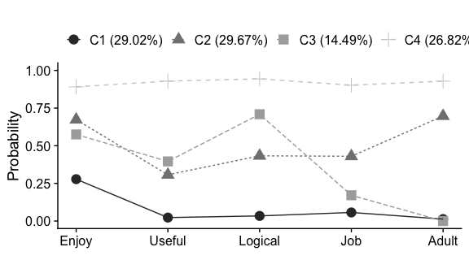

```r
plot_lta_function(
  model_name = lta_models$lta.invariant.out,
  item_num = 5,
  class_num = 4,
  timepoint = 1,
  item_labels = c("Enjoy","Useful","Logical","Job","Adult"),
  plot_title = ""
  )
```

```r
ggsave(here("figures", "InvariantLTA_LCAplot.png"), dpi=300, height=5, width=7, units="in")
```

# ________________________________________________________________________

# Examine transition estimates

## Create Table: LTA Transition Estimates

Extract Transitions (Invariant LTA Model)

```r
lta_out <- lta_models[["lta.invariant.out"]][["class_counts"]][["transitionProbs"]][["probability"]] %>%
  as.data.frame(as.numeric())

t_matrix <- tibble(
  "Time1" = c("Anti-Science","Amb. w/ Elevated","Pro-Science","Amb. w/ Minimal"),
  "Anti-Science" = c(lta_out[1,1],lta_out[2,1],lta_out[3,1],lta_out[4,1]),
  "Amb. w/ Elevated" = c(lta_out[5,1],lta_out[6,1],lta_out[7,1],lta_out[8,1]),
  "Pro-Science" = c(lta_out[9,1],lta_out[10,1],lta_out[11,1],lta_out[12,1]),
  "Amb. w/ Minimal" = c(lta_out[13,1],lta_out[14,1],lta_out[15,1],lta_out[16,1]))
```

Format table

```r
t_matrix %>%
  gt(rowname_col = "Time1") %>%
  tab_stubhead(label = "7th grade") %>%
  tab_header(
    title = md("**Student transitions from 7th grade (rows) to 10th grade (columns)**"),
    subtitle = md("&nbsp;")) %>%
  fmt_number(2:5,decimals = 2) %>%
  tab_spanner(label = "10th grade",columns = 2:5) %>%
  tab_footnote(
    footnote = md("*Note.* Transition estimates for the invariant LTA model."),
    locations = cells_title()
    )
```

**Student transitions from 7th grade (rows) to 10th grade (columns)**<sup>1</sup>

[output not shown]

<sup>1</sup> *Note.* Transition estimates for the invariant LTA model.

## Plot LTA transitions

**NOTE:** The function found in `plot_transitions_function.R` is specific to a model with 2 time-points and 4-classes & must be updated to accommodate other models.

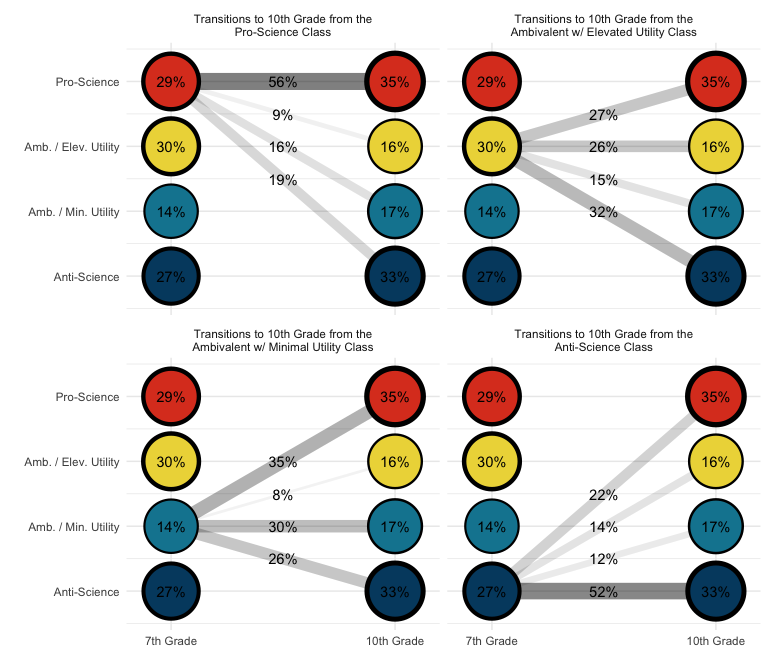

```r
source("plot_transitions_function.R") # Script is located in the project repository

plot_transitions_function(
  model_name = lta_models$lta.invariant.out,
  color_pallete = pnw_palette("Bay", n=4, type = "discrete"),
  facet_labels =c(
    `1` = "Transitions to 10th Grade from the Pro-Science Class",
    `2` = "Transitions to 10th Grade from the Ambivalent w/ Elevated Utility Class",
    `3` = "Transitions to 10th Grade from the Ambivalent w/ Minimal Utility Class",
    `4` = "Transitions to 10th Grade from the Anti-Science Class"),
  timepoint_labels = c('1' = "7th Grade", '2' = "10th Grade"),
  class_labels = c(
    "Pro-Science",
    "Amb. / Elev. Utility",
    "Amb. / Min. Utility",
    "Anti-Science"))
```

```r
ggsave(here("figures","LTA_transition_plot.png"), dpi=500, height=7, width=8, units="in")
```

# ________________________________________________________________________

# References

Hallquist, Michael N., and Joshua F. Wiley. 2018. “MplusAutomation: An R Package for FacilitatingLarge-Scale Latent Variable Analyses in Mplus.” Structural Equation Modeling, 1–18. https://doi.org/10.1080/10705511.2017.1402334.

Miller, Jon D. Longitudinal Study of American Youth (LSAY), Seventh Grade Data, 1987-1988; 2015-2016. Ann Arbor, MI: Inter-university Consortium for Political and Social Research [distributor], 2019-04-23. https://doi.org/10.3886/ICPSR37287.v1

Müller, Kirill. 2017.Here: A Simpler Way to Find Your Files. https://CRAN.R-project.org/package=here.

Muthén, B., & Asparouhov, T. (2020). Latent transition analysis with random intercepts (RI-LTA). Psychological Methods. Advance online publication. https://doi.org/10.1037/met0000370

Muthén L.K., & Muthen B.O. (1998-2017) Mplus User’s Guide. Eight Edition. Los Angelos, CA: Muthen & Muthen.

R Core Team. 2019.R: A Language and Environment for Statistical Computing. Vienna, Austria: R Foundation for Statistical Computing. https://www.R-project.org/.

Wickham H, Averick M, Bryan J, Chang W, McGowan LD, François R, Grolemund G, Hayes A, Henry L, Hester J, Kuhn M, Pedersen TL, Miller E, Bache SM, Müller K, Ooms J, Robinson D, Seidel DP, Spinu V, Takahashi K, Vaughan D, Wilke C, Woo K, Yutani H (2019). “Welcome to the tidyverse.” Journal of Open Source Software, 4(43), 1686. doi: 10.21105/joss.01686.